# R Notebook

# Task 1.

Load the data again, clean_names(), and re-familiarise yourself with it

```r
ames <- read_csv("data/ames.csv") %>%
  clean_names()
```

# Task 2.

Investigate the distribution of lot_area. Is the distribution roughly normal? If not, what problems do you find?

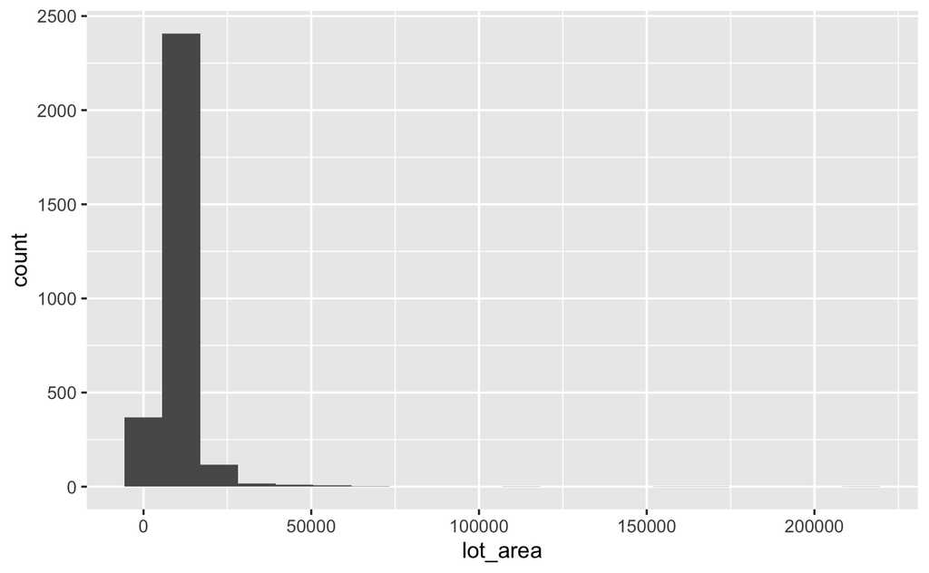

# Task 3.

Compute and visualise a bootstrap sampling distribution for the mean(lot_area) of the sold houses.

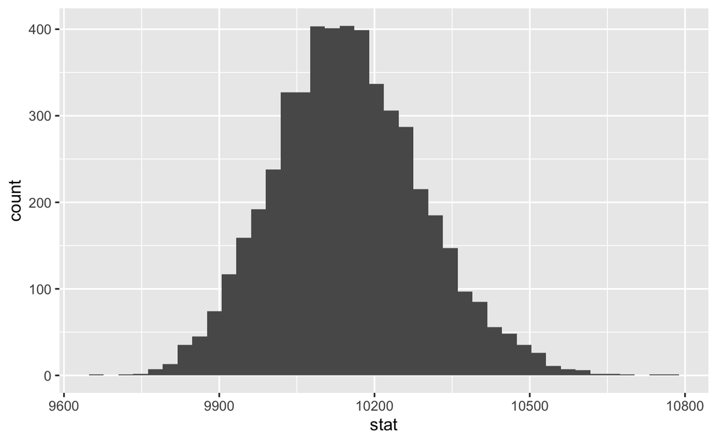

# Task 4.

Use your bootstrap distribution to calculate a 95%

CI for mean(lot_area), and visualise it on the distribution

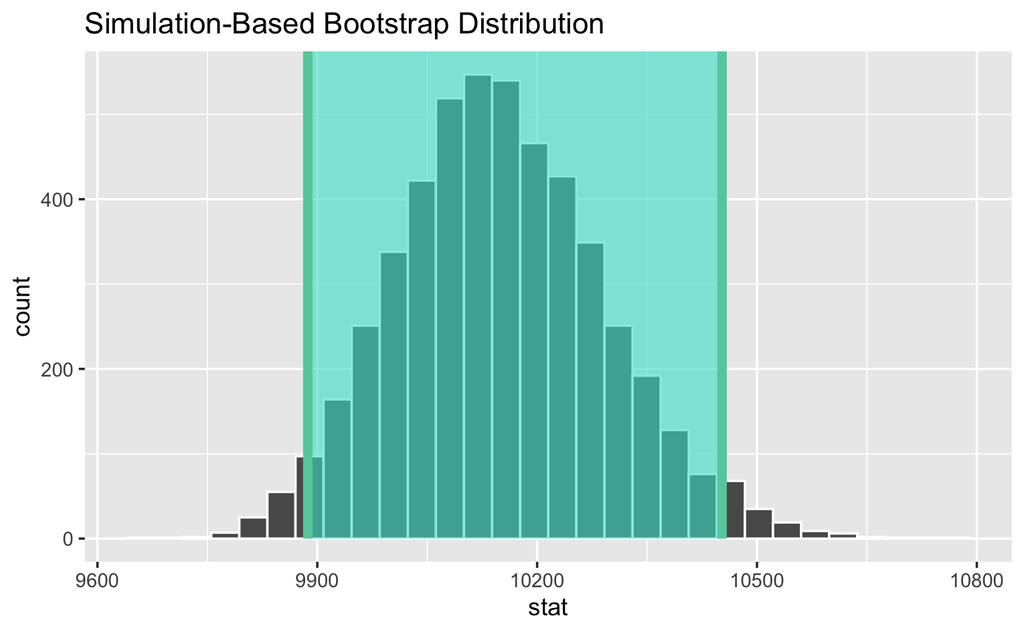

# Task 5.

You would like to know the mean(lot_area) of the sold houses with higher confidence. Calculate the 99% CI for this variable (you can re-use your bootstrap distribution from above). Is it narrower or broader than the 95%

CI? Does that make sense?

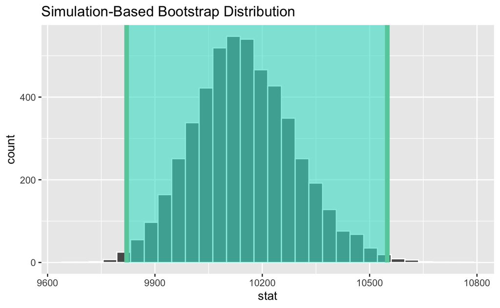

# Task 6.

Calculate the point estimate of the mean(lot_area)

| mean |
| --- |
| 10150.03 |

# 2 Extension

## Task 1.

Calculate a point estimate and 95% CI for the proportion of houses in the data built before 1920. Does the number of reps you use matter? [Investigate reps from 200 up to 50000, memory of your laptop permitting].

[output not shown]

[output not shown]

[output not shown]

[output not shown]

[output not shown]